# Modern Data Mining, HW 1

Daniel Park

Elliot Banks

Wilson Zhang

Due: 11:59PM, Feb 1, 2026

# 1 Case study 1: Audience Size

## 1.1 Data preparation

### 1.1.1 Handling missing/wrongly filled values of the selected variables

```
##       age    gender education    income    sirius   wharton  worktime
##         1         6         0         6         5         4         0
```

```
## # A tibble: 17 × 7
##    age   gender education                         income sirius wharton worktime
##    <chr> <chr>  <chr>                             <chr>  <chr>  <chr>   <chr>
##  1 53    Male   Some college, no diploma; or Ass… <NA>   Yes    No      28
##  2 19    Male   Some college, no diploma; or Ass… $75,0… <NA>   No      25
##  3 <NA>  Male   select one                        <NA>   <NA>   <NA>    5
##  4 29    Female Bachelor’s degree or other 4-yea… <NA>   Yes    No      22
##  5 32    Male   Some college, no diploma; or Ass… $15,0… <NA>   No      37
##  6 36    Female Graduate or professional degree   $75,0… <NA>   No      20
##  7 47    <NA>   Graduate or professional degree   $30,0… Yes    No      54
##  8 21    Male   select one                        <NA>   <NA>   <NA>    4
##  9 49    Male   High school graduate (or equival… <NA>   No     No      14
## 10 25    Female High school graduate (or equival… $30,0… Yes    <NA>    15
## 11 35    Female Some college, no diploma; or Ass… <NA>   Yes    No      18
## 12 47    <NA>   Graduate or professional degree   $50,0… Yes    No      15
## 13 29    <NA>   Some college, no diploma; or Ass… $15,0… Yes    No      19
## 14 31    <NA>   Graduate or professional degree   $30,0… No     No      15
## 15 25    <NA>   Some college, no diploma; or Ass… Less … Yes    No      19
## 16 34    Female Bachelor’s degree or other 4-yea… $50,0… Yes    <NA>    16
## 17 67    <NA>   Some college, no diploma; or Ass… $50,0… No     No      32
```

```
## # A tibble: 19 × 7
##    age   gender education  income             sirius wharton worktime
##    <chr> <chr>  <chr>      <chr>              <chr>  <chr>   <chr>
##  1 23    Female select one $15,000 - $30,000  Yes    No      13
##  2 36    Male   select one $15,000 - $30,000  No     No      17
##  3 26    Male   select one $30,000 - $50,000  Yes    No      17
##  4 18    Male   select one Above $150,000     No     No      11
##  5 32    Female select one $30,000 - $50,000  Yes    Yes     35
##  6 <NA>  Male   select one <NA>               <NA>   <NA>    5
##  7 47    Female select one $75,000 - $150,000 Yes    No      19
##  8 28    Male   select one Less than $15,000  No     No      17
##  9 47    Female select one $15,000 - $30,000  Yes    No      36
## 10 21    Male   select one <NA>               <NA>   <NA>    4
## 11 49    Male   select one Less than $15,000  Yes    No      18
## 12 53    Female select one $15,000 - $30,000  No     No      40
## 13 34    Female select one $15,000 - $30,000  No     No      15
## 14 47    Female select one Above $150,000     Yes    No      22
## 15 67    Male   select one $50,000 - $75,000  Yes    No      28
## 16 27    Female select one $30,000 - $50,000  Yes    No      23
## 17 26    Male   select one $30,000 - $50,000  Yes    No      23
## 18 24    Female select one $30,000 - $50,000  Yes    No      37
## 19 54    Female select one $50,000 - $75,000  Yes    No      28
```

```
##       age    gender education    income    sirius   wharton  worktime
##         0         6         0         5         0         0         0
```

The first table shows entries that have an NA value and the second table shows entries which have “select one” as the education type.

It is evident that there are a mix of different attributes which are missing.

1. Age: There is one entry with no age. That row will be invalidated, as all people have ages.
2. Gender: There are a couple entries with no gender. Looking at the data manually, the only other genders are Male and Female. People may identify with different genders, explaining the NA entries.
3. Education: No entries are NA, however there were 19 entries that had “select one”. These entries have been renamed to “Other”.
4. Income: NA income entries are be interpreted as the survey participant being unemployed.
5. Sirius / Wharton: NA entries will be treated as false.

## 1.2 Brief summary

We will first observe the level of education and income for the survey participants.

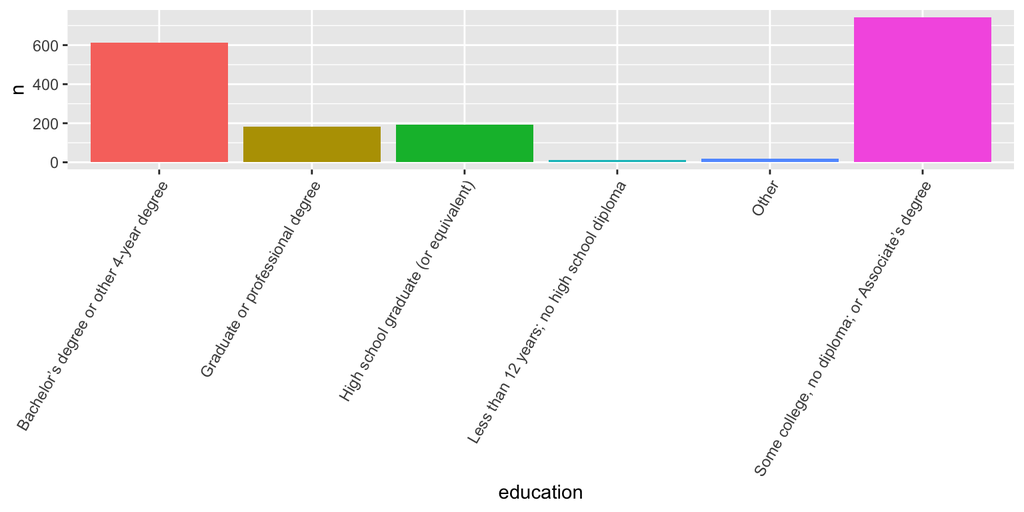

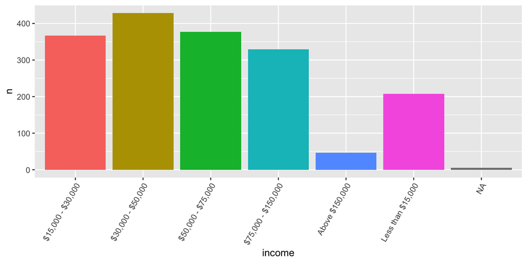

The majority of survey takers (744 people) have some college experience, or an Associate’s degree. The second most common education level is a Bachelors / Other 4 Year degree, with 614 entries.

Most survey takers (429) had an income in the range of $30,000 - $50,000. The bulk of the participants have incomes within $15,000 - $75,000, with very few outside of that range (<$15k, 208), (>$150k, 47). Even though high-income respondents are rare, they are disproportionately more likely to listen to Wharton Radio.

### 1.2.1 Listen Rate vs Age

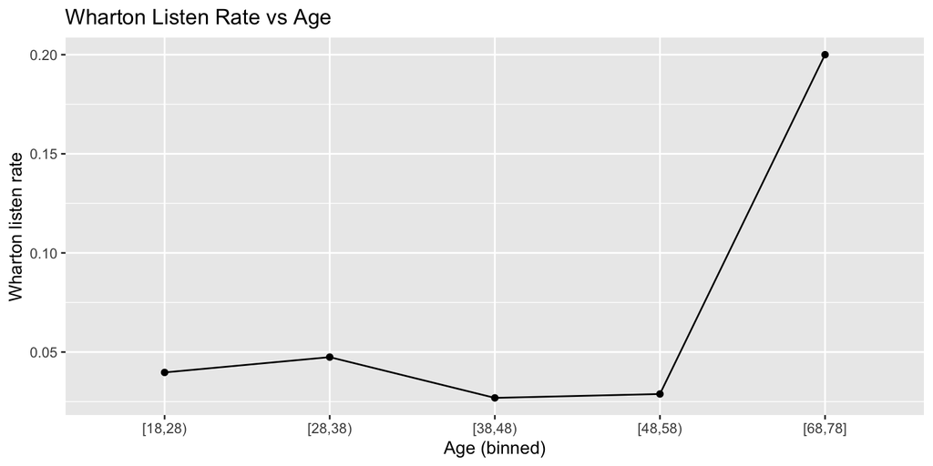

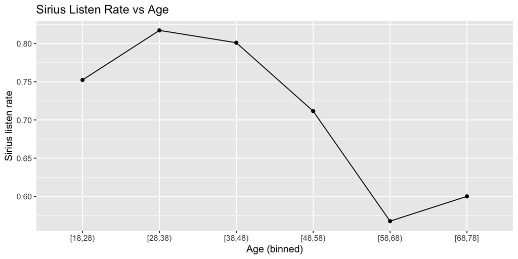

The listening rate of the two radio stations as a function of age was graphed. The listening rates on average were substantially lower for Wharton compared to Sirius. Additionally, there were no survey takers in the age range of 58-68 who listened to the Wharton talk show.

There was a significant rise in listening rates for participants ages 68-78 for the Wharton talk show compared to younger participants. The overall trend for the Wharton talk show suggests an increase in listen rate as age increases. The sirius listen rate has the opposite relationship, with the listening rate peaking for ages 28-38 with a listening rate of almost 82.5%, before dropping by a substantial amount as age increases, down to around a 57% listen rate for ages 58-68, before increasing marginally to 60% for ages 68-78.

### 1.2.2 Listen Rate vs Income

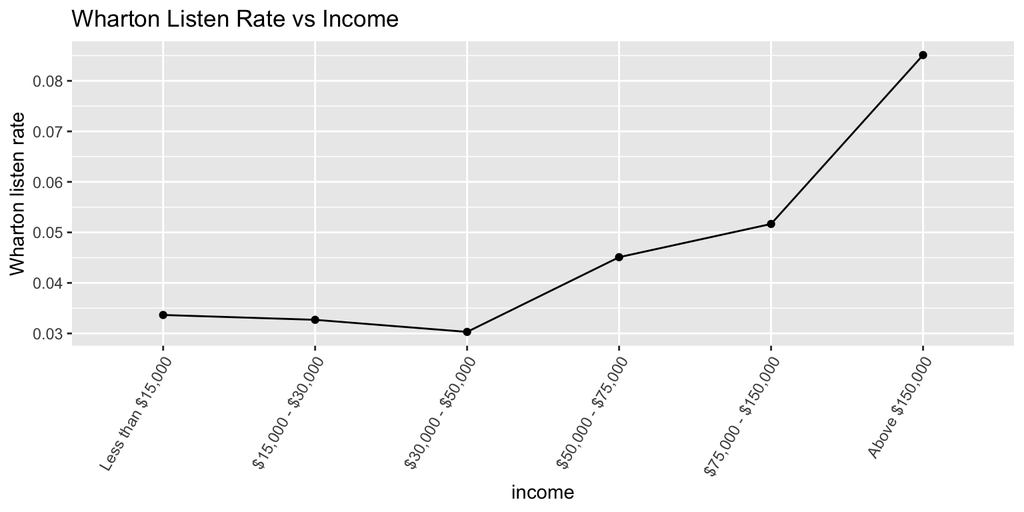

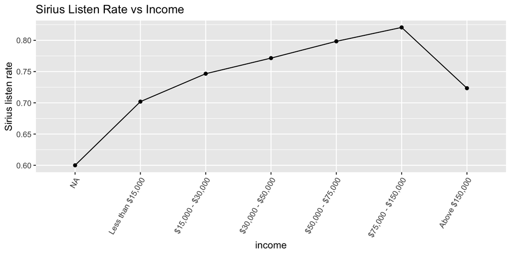

Plotting the listen rate as a function of income shows additional insights. For the Wharton talk show, we can see that as income increases, the listen rate increases as well. Participants with income below $50,000 all have similar listening rates, around 3-3.5%.

Sirius listening rates show a more consistent rise as income increases, however at the high income levels (>$150,000), the listening rates drop by around 10%, a significant margin.

### 1.2.3 Addressing Why Individuals Take Survey Despite Low Compensation

When observing the sample data, we can see that there was a variety of income levels listed despite the monetary compensation for the survey being on 10 cents. Despite this small compensation, a number of respondents report relatively high household incomes. This does not necessarily imply that these individuals rely on these surveys as a primary source of income, but they may rather complete them out of curiosity, habit, or leisure, when the opportunity cost of a short task is negligible. Additionally, reported household income may reflect shared income within a household rather than the respondent’s personal earnings.

## 1.3 Sample properties

The population from which the sample is drawn determines where the results of our analysis can be applied or generalized. We include some basic demographic information for the purpose of identifying sample bias, if any exists. Combine our data and the general population distribution in age, gender and income to try to characterize our sample on hand.

### 1.3.1 Does this sample appear to be a random sample from the general population of the USA? Why it is crucial to have randomness here?

```
## # A tibble: 7 × 3
##   income                 n percent
##   <ord>              <int>   <dbl>
## 1 NA                     5   0.284
## 2 Less than $15,000    208  11.8
## 3 $15,000 - $30,000    367  20.8
## 4 $30,000 - $50,000    429  24.3
## 5 $50,000 - $75,000    377  21.4
## 6 $75,000 - $150,000   329  18.7
## 7 Above $150,000        47   2.67
```

```
## # A tibble: 3 × 3
##   gender     n percent
##   <chr>  <int>   <dbl>
## 1 Female   744  42.2
## 2 Male    1012  57.4
## 3 <NA>       6   0.341
```

```
## # A tibble: 6 × 3
##   age_bin     n percent
##   <fct>   <int>   <dbl>
## 1 [18,28)   856  48.7
## 2 [28,38)   569  32.4
## 3 [38,48)   186  10.6
## 4 [48,58)   104   5.92
## 5 [58,68)    37   2.11
## 6 [68,78]     5   0.285
```

We will cover the distribution of income first.

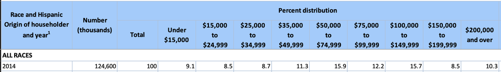

Distribution of US Household Income 2014, United States Census

Comparing the percentage distributions of income, we observe the following:

1. Income levels up to $75,000 are over-represented:
   - Under $15,000: 11.8% vs 9.1% (U.S. population)
   - $15,000–$50,000: 45.176% vs 28.5% (U.S. population)
   - $50,000–$75,000: 21.396% vs 15.9% (U.S. population)
2. Income levels above $75,000 are under-represented:
   - $75,000–$150,000: 18.672% vs 27.9% (U.S. population)
   - Above $150,000: 2.667% vs 18.8% (U.S. population)

Overall, higher-income households are substantially under-represented in the survey sample, while lower-income households (below $75,000) are over-represented relative to the U.S. population.

Now analyzing gender, there were 744 Females and 1012 Males. Males represent 57.435% of the survey population, which is a slight over-representation compared to the US average of 51%.

The younger generation is over-represented, while the older generation is under-represented. This is likely attributed to the familiarity of technology to different age groups.

1. Individuals aged between 18-38 are over-represented.
   - 18–28: 48.719% vs 13.5% (reality)
   - 28–38: 32.285% vs 14.1% (reality)
2. Individuals aged between 38-78 are under-represented.
   - 38–48: 10.586% vs 13.1% (reality)
   - 48–58: 5.919% vs 12.2% (reality)
   - 58–68: 2.106% vs 12.1% (reality)
   - 68–78: 0.285% vs 9.2% (reality) (Data was taken from US census data, 2014)

### 1.3.2 Does this sample appear to be a random sample from the MTURK population?

Analysing income distribution of MTurk Users:

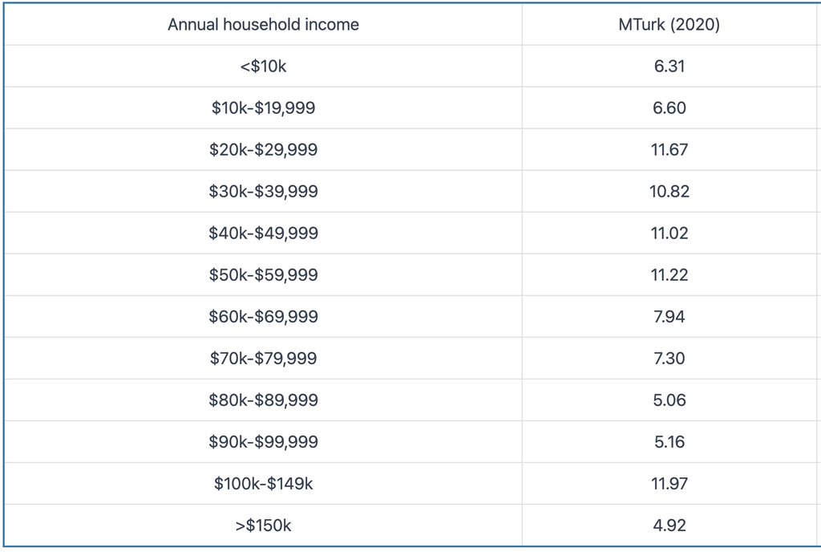

The survey data represents the middle income range fairly well, however it over-represents lower income levels and under-represents higher income levels.

**$50k - $150k**: 40.1% vs 48.65 (MTurk) - Under-represented

**Above $150k**: 2.67% vs 4.92% (MTurk) - Slightly under-represented.

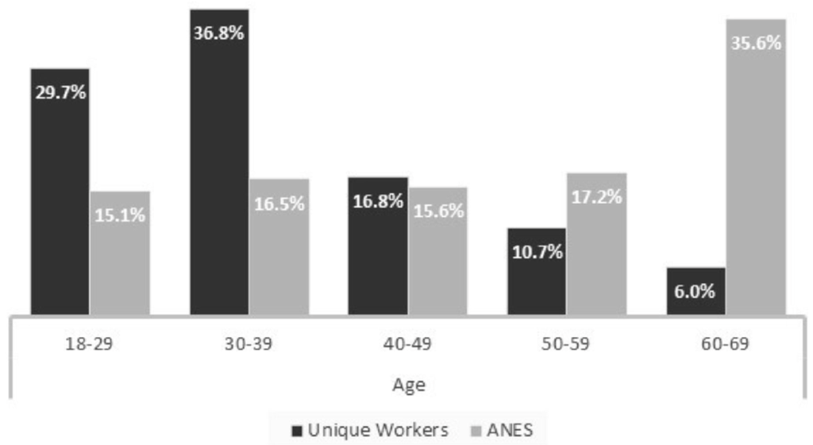

Age Distribution of MTurk Users

The survey data broadly reflects the age structure of the MTurk population, but it substantially over-represents younger respondents and under-represents older respondents.

Overall, the survey sample is noticeably younger than the MTurk population. Nearly half of respondents fall in the youngest age group, while older age groups-particularly those above age 60 are under represented. This suggests that, although the sample is drawn from MTurk, age-related selection effects may influence the estimated listening behavior.

## 1.4 Final estimate

Provide an approximate **95% confidence interval** of the Wharton audience size by May of 2014. Assume that the sample is a random sample of the MTURK population, and that the proportion of Wharton listeners vs. Sirius listeners in the general population is the same as that in the MTURK population. Write a brief executive summary to summarize your findings and how you came to that conclusion.

### 1.4.1 Goal of the study

The goal of this study was to estimate the audience size of Business Radio Powered by the Wharton School in May 2014, based on survey data collected from U.S. based respondents.

### 1.4.2 Method used: data gathering, estimation methods

```
## [1] 0.05
```

```
## [1] 0.0384 0.0616
```

```
## [1] 1983770 3180026
```

```
## [1] 2581898
```

### 1.4.3 Findings

Wharton listeners represent about 5% of the MTurk Population. The estimated Wharton Business Radio audience size is approximately 2.6 million listeners, with a 95% confidence interval ranging from 2.0 million to 3.2 million listeners.

### 1.4.4 Limitations of the study.

This estimate relies on the assumption that the Mechanical Turk sample is representative of the Sirius listener population with respect to Wharton listening behavior. However, earlier analyses show that the sample differs from the general U.S. population in age, income, and gender, and MTurk workers may exhibit systematic differences in media consumption. As a result, while the confidence interval captures some of the sampling variability, it does not account for potential selection bias, population distribution and hence, the true audience size may lie outside the reported range.

## 1.5 New task

### 1.5.1 Proposal: Estimating the Current Audience Size of Wharton Business Radio (Budget: $1000, Timeline: 2 months)

#### 1.5.1.1 1) Method

We will estimate the number of current listeners as follows:

1. Collect U.S. adult samples to identify individuals who are SiriusXM listeners
2. Within the SiriusXM listener subset, estimate the proportion who have listened to Wharton Business Radio in the last 30 days. Let p be the estimated proportion of Wharton listeners among SiriusXM listeners. We will multiply p by a credible estimate of the **current SiriusXM listener/subscriber base** from public sources to obtain an estimated audience size. A 95% confidence interval will be computed using a standard CI for a proportion and scaled to the population size.

#### 1.5.1.2 2) Data to collect and sources

**Survey variables**

- SiriusXM listening status (Yes/No, past 30 days)
- Wharton Business Radio listening status (Yes/No, past 30 days)
- Listening frequency (approximate minutes per week, past 30 days)
- Medium of Listening (car radio, SiriusXM app, podcast replay, other)
- Demographics for weighting: age, gender, education, household income, region/state

**Collection of Data**

We will use:

- **Prolific** platform to collect data, a platform which “helps AI developers, researchers, and organizations easily access the highest-quality human data” (Prolific)
- Publicly available estimates of **current SiriusXM subscriber/listener base** (For example, company reports/filings or reputable summaries).

**Budgeting** The $1000 budget will be distributed as follows:

- Participant incentives (~$850): Used to recruit approximately 700–900 U.S.-based respondents on Prolific for a 5-7 minute survey. Incentive rates are set to meet platform minimums while ensuring response quality is sufficient.
- Platform and service fees (~$100):  
  Covers Prolific service fees and any additional costs associated with the collection of data.
- Contingency and pilot testing (~$50): Reserved for a small pilot survey to test question clarity and for additional responses if data quality issues arise.

**Pros and Cons**

Pros

- Access to a high-quality, pre-screened participant pool with reliable demographic information
- Better data quality and fewer bots or low-effort responses compared to MTurk
- Ability to target U.S. respondents and apply demographic quotas, reducing sampling bias
- Cost-effective for small to medium-sized academic studies within a limited budget

Cons:

- More expensive per response than MTurk, limiting maximum sample size
- Still not fully representative of the general U.S. population, requiring weighting and careful interpretation

**Use of ChatGPT**

ChatGPT can assist with survey wording, analysis planning, and drafting of the reports, but it will not be used as an empirical source for audience size, as the data sources that it pulls cannot easily be verified, and ChatGPT can also hallucinate, providing incorrect modelling data.

**Final Deliverable**

Point estimate + 95% CI for current audience size, as well as outlining the limitations of the data collected in relation to several factors, such as potential selection bias arising from the survey platform, and uncertainty in extrapolating survey proportions to the broader listening population.

# 2 Case study 2: Women in Science

Are women underrepresented in science in general? How does gender relate to the type of educational degree pursued? Does the number of higher degrees increase over the years? In an attempt to answer these questions, we assembled a data set (`WomenData_06_16.xlsx`) from [NSF](https://ncses.nsf.gov/pubs/nsf19304/digest/field-of-degree-women) about various degrees granted in the U.S. from 2006 to 2016. It contains the following variables: Field (Non-science-engineering (`Non-S&E`) and sciences (`Computer sciences`, `Mathematics and statistics`, etc.)), Degree (`BS`, `MS`, `PhD`), Sex (`M`, `F`), Number of degrees granted, and Year.

Our goal is to answer the above questions only through EDA (Exploratory Data Analyses) without formal testing. We have provided sample R-codes in the appendix to help you if needed.

## 2.1 Data preparation

### 2.1.1 Understand and clean the data

Notice the data came in as an Excel file. We need to use the package `readxl` and the function `read_excel()` to read the data `WomenData_06_16.xlsx` into R.

#### 2.1.1.1 Read the data into R.

#### 2.1.1.2 Clean the names of each variables. (Change variable names to `Field`,`Degree`, `Sex`, `Year` and `Number` )

```
## [1] "Field and sex"   "Degree"          "Sex"             "Year"
## [5] "Degrees Awarded"
```

```
## [1] "Field"  "Degree" "Sex"    "Year"   "Number"
```

#### 2.1.1.3 Set the variable natures properly.

```
##                                     Field     Degree        Sex
##  Agricultural sciences                 : 66   BS :220   Female:330
##  Biological sciences                   : 66   MS :220   Male  :330
##  Computer sciences                     : 66   PhD:220
##  Earth, atmospheric, and ocean sciences: 66
##  Engineering                           : 66
##  Mathematics and statistics            : 66
##  (Other)                               :264
##       Year          Number
##  Min.   :2006   Min.   :   218
##  1st Qu.:2008   1st Qu.:  2118
##  Median :2011   Median :  6020
##  Mean   :2011   Mean   : 41717
##  3rd Qu.:2014   3rd Qu.: 18127
##  Max.   :2016   Max.   :781474
##
```

#### 2.1.1.4 Any missing values?

```
##  Field Degree    Sex   Year Number
##      0      0      0      0      0
```

### 2.1.2 Write a summary describing the data set provided here.

#### 2.1.2.1 How many fields are there in this data?

```
## [1] 660   5
```

There are 5 different variables (Field, Degree, Sex, Year and Number), and 660 data entries in the data set.

#### 2.1.2.2 What are the degree types?

```
##  [1] Agricultural sciences
##  [2] Biological sciences
##  [3] Computer sciences
##  [4] Earth, atmospheric, and ocean sciences
##  [5] Mathematics and statistics
##  [6] Physical sciences
##  [7] Psychology
##  [8] Social sciences
##  [9] Engineering
## [10] Non-S&E
## 10 Levels: Agricultural sciences Biological sciences ... Social sciences
```

#### 2.1.2.3 How many year’s statistics are being reported here?

```
## [1] 10
```

## 2.2 BS degrees in 2015

### 2.2.1 Is there evidence that more males are in science-related fields vs `Non-S&E`? Provide summary statistics and a plot which shows the number of people by gender and by field. Write a brief summary to describe your findings.

The number of males and females in S&E were relatively similar in 2015 with 327,122 and 322,935 people graduating respectively. This is visualised in the Bar Chart where the bars for Male and Female S&E Graduates is essentially the same. Furthermore, this shows that there are many more gradutes in non-S&E courses compared with S&E courses. However, this could be attributed to a limited range of degrees available in S&E courses compared with non-S&E courses.

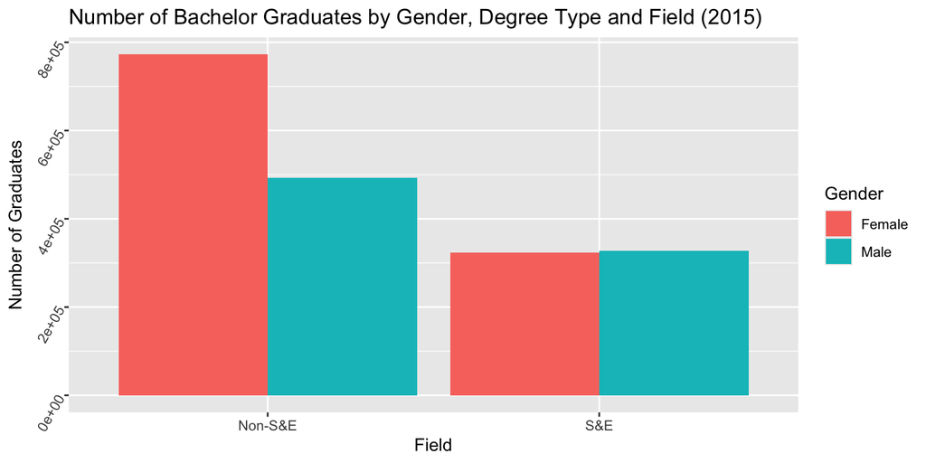

Summary statistics by S&E group and gender in 2015

| SE | Sex | Total |
| --- | --- | --- |
| Non-S&E | Female | 772768 |
| Non-S&E | Male | 493304 |
| S&E | Female | 322935 |
| S&E | Male | 327122 |

## 2.3 EDA bringing type of degree, field and gender in 2015

### 2.3.1 Describe the number of people by type of degree, field, and gender. Do you see any evidence of gender effects over different types of degrees? Again, provide graphs to summarize your findings.

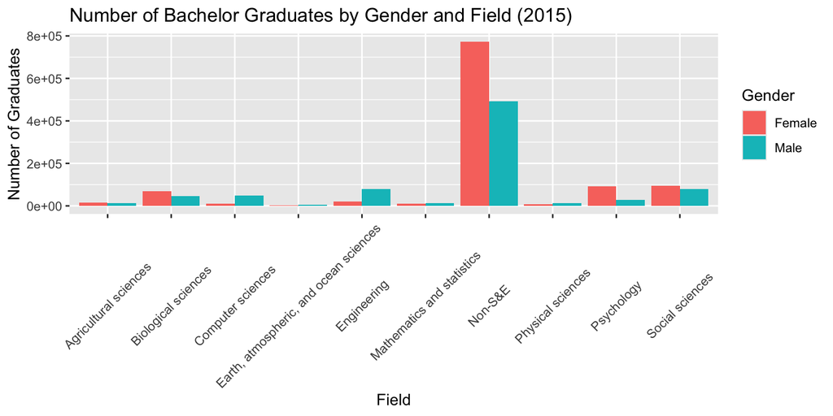

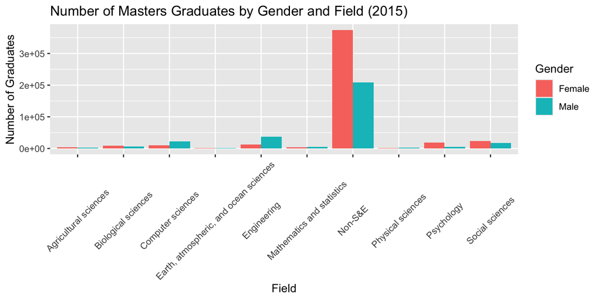

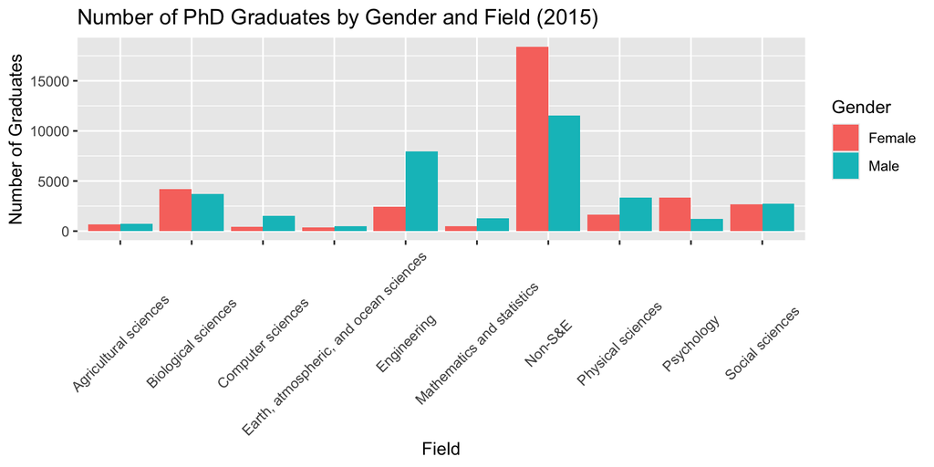

## 2.4 EDA bring all variables

### 2.4.1 In this last portion of the EDA, we ask you to provide evidence numerically and graphically: Do the number of degrees change by gender, field, and time?

Overtime, females have consistently had more graduates in subject areas including Agricultural Sciences, Biological Sciences, Non-S&E, Psychology and Social Sciences. This differs to Computer Science, Earth, Atmospheric and Ocean Sciences, Engineering, Mathematics and Statistics and Physical Sciences which have consistently more male graduates each year.

All subject areas have experienced strong growth in graduate numbers, however, Earth, Atmospheric and Ocean Sciences, and Social Sciences have experienced slower growth in the past three years, with Social Sciences even falling in popularity.

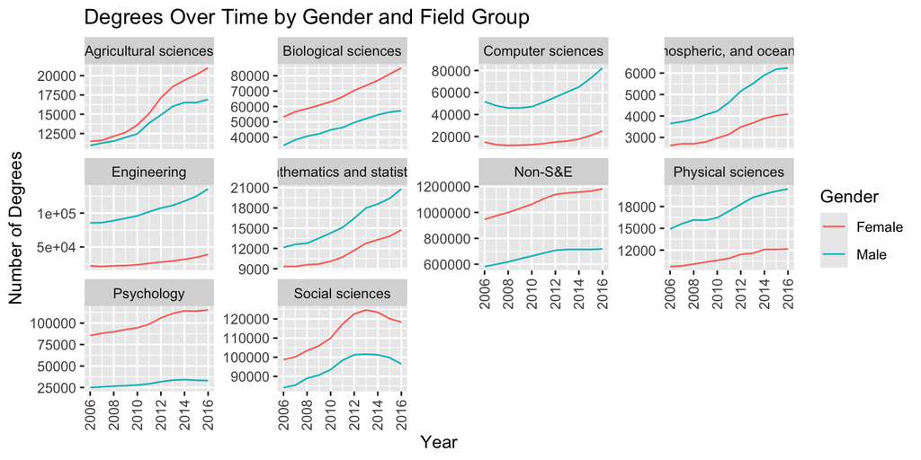

## 2.5 Women in Data Science

### 2.5.1 Finally, is there evidence showing that women are underrepresented in data science? Data science is an interdisciplinary field of computer science, math, and statistics. You may include year and/or degree.

Yes, females have been underrepresented in data science consistently across the decade. Whilst the total number of females studying this subject area have increased from 10,000 to 12,000, they are still significantly less than the current 53,000 males gradutates, and have experienced much slower growth in popularity compared with the 15,000 increase in males.

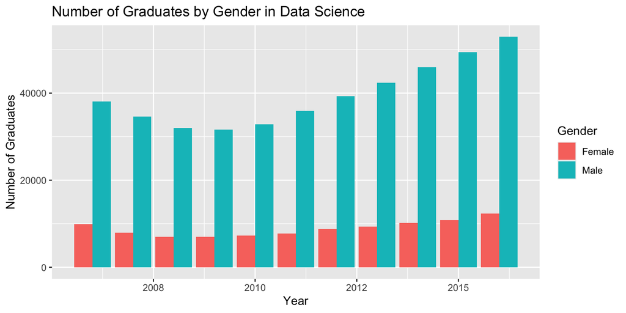

## 2.6 Final brief report

### 2.6.1 Summarize your findings focusing on answering the questions regarding if we see consistent patterns that more males pursue science-related fields. Any concerns with the data set? How could we improve on the study?

Over the 10 year study, we consistently see males pursuing science-related fields more than females. Moreover, this gender gap has almost doubled over this time period.

This study raised no issues about the integrity or quality of the data set. An addition could be considering individuals who study majors from different schooles (S&E and non-S&E). The reason for why females are underrepresented may be because they are not having their full degree structure reported in this study (e.g. someone could major in English and Chemistry in an Arts Degree - this would be shown as Non-S&E).

To improve this study this experiment should be repeated numerous times, improving validity and reliability. Furthermore, it should be conducted across multiple universities in the same region, limiting the impact of potential bias from the current test population.

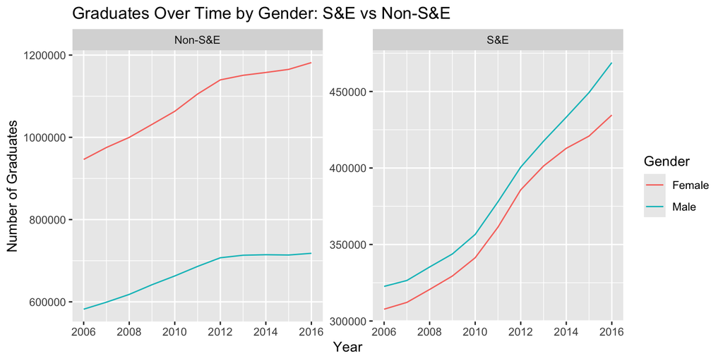

# 3 Case study 3: Major League Baseball

We would like to explore how payroll affects performance among Major League Baseball teams. The data is prepared in two formats record payroll, winning numbers/percentage by team from 1998 to 2014.

Here are the datasets:

- `MLPayData_Total.csv`: wide format
- `baseball.csv`: long format

Feel free to use either dataset to address the problems.

## 3.1 Loading Data

```r
pay_data <- read_csv("data/MLPayData_Total.csv")
team_data <- read_csv("data/Baseball.csv")
```

## 3.2 EDA: Relationship between payroll changes and performance

Payroll may relate to performance among ML Baseball teams. One possible argument is that what affects this year’s performance is not this year’s payroll, but the amount that payroll increased from last year. Let us look into this through EDA.

Create increment in payroll

# 4 4.1 - Relationship between payroll changes and performance

a). To describe the increment of payroll in each year there are several possible approaches. Take 2013 as an example:

Explain why the log difference is more appropriate in this setup.

In describing the increment of payroll in each year, there are several possible approaches. While one approach is to take the difference in payroll between year $x$ and year $x - 1$, another approach is to take $log(x) - log(x - 1)$. The second approach is objectively better as it calculates the percentage change year on year instead of giving an absolute number change. This helps provide a more informative view towards the scale of the payroll increments year on year. Furthermore, a clean property of using the log measure to calculate percentage changes is that in contrast to the typical approach, it maintains symmetry of percentage changes where the percentage increase from $a$ to $b$ is equal to the percentage decrease from $b$ to $a$.

b). Create a new variable `diff_log=log(payroll_2013) - log(payroll_2012)`. Hint: use `dplyr::lag()` function.

## 4.1 Part b)

```r
diff_log <- team_data %>%
  filter(year %in% c(2012, 2013)) %>%
  group_by(team) %>%
  arrange(year, .by_group = TRUE) %>%
  mutate(diff_log = log(payroll) - lag(log(payroll)))

head(diff_log)
```

```
## # A tibble: 6 × 6
## # Groups:   team [3]
##   team                  year payroll win_num win_pct diff_log
##   <chr>                <dbl>   <dbl>   <dbl>   <dbl>    <dbl>
## 1 Arizona Diamondbacks  2012    74.3      81   0.5    NA
## 2 Arizona Diamondbacks  2013    89.1      81   0.5     0.182
## 3 Atlanta Braves        2012    83.3      94   0.580  NA
## 4 Atlanta Braves        2013    89.8      96   0.593   0.0748
## 5 Baltimore Orioles     2012    81.4      93   0.574  NA
## 6 Baltimore Orioles     2013    91.0      85   0.525   0.111
```

c). Create a long data table including: team, year, diff_log, win_pct

```r
team_data <- team_data %>%
  group_by(team) %>%
  arrange(year, .by_group = TRUE) %>%
  mutate(diff_log = log(payroll) - lag(log(payroll)))

head(team_data)
```

```
## # A tibble: 6 × 6
## # Groups:   team [1]
##   team                  year payroll win_num win_pct diff_log
##   <chr>                <dbl>   <dbl>   <dbl>   <dbl>    <dbl>
## 1 Arizona Diamondbacks  1998    31.6      65   0.401 NA
## 2 Arizona Diamondbacks  1999    70.5     100   0.617  0.802
## 3 Arizona Diamondbacks  2000    81.0      85   0.525  0.139
## 4 Arizona Diamondbacks  2001    81.2      92   0.568  0.00220
## 5 Arizona Diamondbacks  2002   103.       98   0.605  0.236
## 6 Arizona Diamondbacks  2003    80.6      84   0.519 -0.243
```

# 5 4.2 - Exploratory Questions

## 5.1 Part a) Which five teams had highest increase in their payroll between years 2010 and 2014, inclusive?

```r
years_of_interest <- c(2010, 2011, 2012, 2013, 2014)

payroll_increase <- team_data %>%
  filter(year %in% years_of_interest) %>%
  group_by(team) %>%
  arrange(year, .by_group = TRUE) %>%
  mutate(increase = log(payroll) - lag(log(payroll), 4)) %>%
  filter(year == 2014) %>%
  ungroup() %>%
  arrange(desc(increase)) %>%
  slice_head(n = 5)

head(payroll_increase)
```

```
## # A tibble: 5 × 7
##   team                  year payroll win_num win_pct diff_log increase
##   <chr>                <dbl>   <dbl>   <dbl>   <dbl>    <dbl>    <dbl>
## 1 Los Angeles Dodgers   2014   235.       94   0.580   0.0828    0.908
## 2 Texas Rangers         2014   136.       67   0.414   0.176     0.901
## 3 San Diego Padres      2014    90.1      77   0.475   0.294     0.869
## 4 Pittsburgh Pirates    2014    78.1      88   0.543  -0.0183    0.804
## 5 Washington Nationals  2014   135.       96   0.593   0.166     0.785
```

## 5.2 Part b) Between 2010 and 2014, inclusive, which team(s) “improved” the most? That is, had the biggest percentage gain in wins?

```r
performance_increase <- team_data %>%
  filter(year %in% years_of_interest) %>%
  group_by(team) %>%
  arrange(year, .by_group = TRUE) %>%
  mutate(per_increase = win_pct - lag(win_pct, 4)) %>%
  filter(year == 2014) %>%
  arrange(desc(per_increase)) %>%
  ungroup()

head(performance_increase)
```

```
## # A tibble: 6 × 7
##   team                  year payroll win_num win_pct diff_log per_increase
##   <chr>                <dbl>   <dbl>   <dbl>   <dbl>    <dbl>        <dbl>
## 1 Pittsburgh Pirates    2014    78.1      88   0.543  -0.0183        0.191
## 2 Baltimore Orioles     2014   107.       96   0.593   0.166         0.185
## 3 Washington Nationals  2014   135.       96   0.593   0.166         0.167
## 4 Seattle Mariners      2014    92.1      87   0.537   0.246         0.160
## 5 Kansas City Royals    2014    92.0      89   0.549   0.122         0.136
## 6 Los Angeles Angels    2014   156.       98   0.605   0.197         0.111
```

# 6 4.3 Do log increases in payroll imply better performance?

Is there evidence to support the hypothesis that higher increases in payroll on the log scale lead to increased performance?

Pick up a few statistics, accompanied with some data visualization, to support your answer.

```r
performance_to_payroll <- team_data %>%
  group_by(team) %>%
  arrange(year, .by_group = TRUE) %>%
  mutate(pay_delta = log(payroll) - lag(log(payroll))) %>%
  mutate(performance_delta = win_pct - lag(win_pct)) %>%
  drop_na() %>%
  ungroup()

total_performance_to_payroll <- team_data %>%
  group_by(team) %>%
  arrange(year, .by_group = TRUE) %>%
  mutate(pay_delta = log(payroll) - lag(log(payroll), 16)) %>%
  mutate(performance_delta = win_pct - lag(win_pct, 16)) %>%
  drop_na() %>%
  ungroup()
```

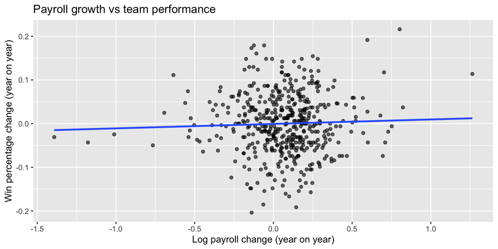

```r
ggplot(performance_to_payroll, aes(x = pay_delta, y = performance_delta)) +
  geom_point(alpha = 0.6) +
  geom_smooth(method = "lm", se = FALSE) +
  labs(
    x = "Log payroll change (year on year)",
    y = "Win percentage change (year on year)",
    title = "Payroll growth vs team performance"
  )
```

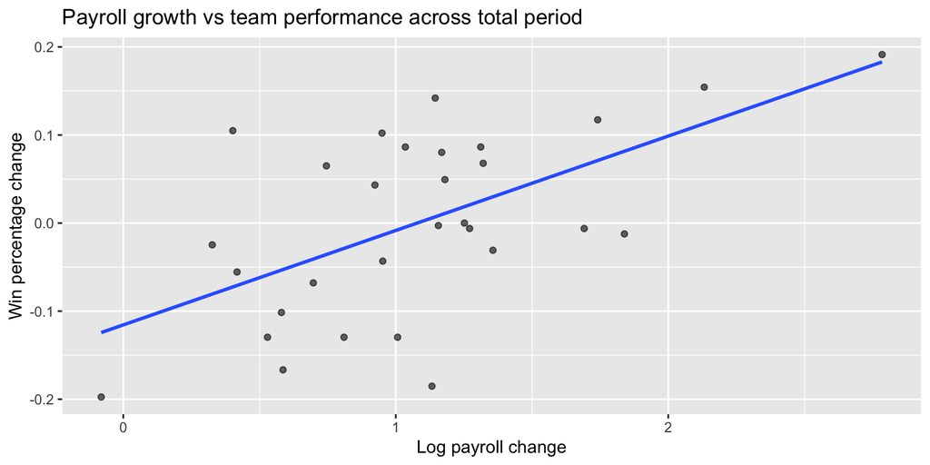

```r
ggplot(total_performance_to_payroll, aes(x = pay_delta, y = performance_delta)) +
  geom_point(alpha = 0.6) +
  geom_smooth(method = "lm", se = FALSE) +
  labs(
    x = "Log payroll change",
    y = "Win percentage change",
    title = "Payroll growth vs team performance across total period"
  )
```

```r
cor(performance_to_payroll$pay_delta,
    performance_to_payroll$performance_delta)
```

```
## [1] 0.0377
```

```r
model <- lm(performance_delta ~ pay_delta,
            data = performance_to_payroll)

summary(model)
```

```
##
## Call:
## lm(formula = performance_delta ~ pay_delta, data = performance_to_payroll)
##
## Residuals:
##      Min       1Q   Median       3Q      Max
## -0.20160 -0.04498 -0.00124  0.04373  0.20855
##
## Coefficients:
##              Estimate Std. Error t value Pr(>|t|)
## (Intercept) -0.000685   0.003267   -0.21     0.83
## pay_delta    0.010201   0.012378    0.82     0.41
##
## Residual standard error: 0.0692 on 478 degrees of freedom
## Multiple R-squared:  0.00142,    Adjusted R-squared:  -0.00067
## F-statistic: 0.679 on 1 and 478 DF,  p-value: 0.41
```

From the data provided above, we can see that there is very little correlation between log payroll increases and petter team performance. In the graphs, we can observe that while the slope is positive, it is extremely small, indicating a very weak linear relationship. This is further supported by the correlation value of **0.0377** which is close to 0 or no correlation. Furthermore, the low $R^2$ value of **0.00142** indicates that payroll changes explain only 0.14% of the variation in performance changes, meaning that this model has almost no explanatory power. Therefore, we can conclude that log payroll increases do not lead to better team performance.

## 6.1 Comparison

# 7 4.4 - Comparison

```r
model_one <- lm(win_pct ~ pay_delta,
            data = performance_to_payroll)

model_two <- lm(win_pct ~ log(payroll),
            data = performance_to_payroll)

summary(model_one)
```

```
##
## Call:
## lm(formula = win_pct ~ pay_delta, data = performance_to_payroll)
##
## Residuals:
##      Min       1Q   Median       3Q      Max
## -0.22615 -0.05395  0.00185  0.05384  0.20756
##
## Coefficients:
##             Estimate Std. Error t value Pr(>|t|)
## (Intercept)  0.49685    0.00332   149.8  < 2e-16 ***
## pay_delta    0.04656    0.01257     3.7  0.00024 ***
## ---
## Signif. codes:  0 '***' 0.001 '**' 0.01 '*' 0.05 '.' 0.1 ' ' 1
##
## Residual standard error: 0.0703 on 478 degrees of freedom
## Multiple R-squared:  0.0279, Adjusted R-squared:  0.0259
## F-statistic: 13.7 on 1 and 478 DF,  p-value: 0.000236
```

```r
summary(model_two)
```

```
##
## Call:
## lm(formula = win_pct ~ log(payroll), data = performance_to_payroll)
##
## Residuals:
##      Min       1Q   Median       3Q      Max
## -0.21372 -0.04781  0.00423  0.05084  0.21355
##
## Coefficients:
##              Estimate Std. Error t value Pr(>|t|)
## (Intercept)   0.26805    0.02732    9.81   <2e-16 ***
## log(payroll)  0.05419    0.00634    8.54   <2e-16 ***
## ---
## Signif. codes:  0 '***' 0.001 '**' 0.01 '*' 0.05 '.' 0.1 ' ' 1
##
## Residual standard error: 0.0664 on 478 degrees of freedom
## Multiple R-squared:  0.132,  Adjusted R-squared:  0.131
## F-statistic:   73 on 1 and 478 DF,  p-value: <2e-16
```

# 8 4.5 - Going beyond EDA

Going forward, a more reasonable way to study the relationship between payroll and team performance beyond simple plots would be by using linear regression alongside more statistical analysis including the $R^2$ value, model comparisons and slope tests.

Process: In performing my analysis, GAI, particularly the Chat-GPT model, guided my analysis by suggesting further methods of testing the relationships between the given variables, in particular linear regression and interpreting the $R^2$ value. As such, I incorporated such features into my analysis and drew upon their data in reaching a conclusion for the previous questions.

These methods are better than the basic EDA methods as it uses formal statistical models rather than just relying on visual patterns. Furthermore, it quantifies relationships using measures such as correlations allowing for direct comparison of measures such as payrolls or increasing payrolls. Furthermore, it reduces the risk of formulating incorrect conclusions because of noisy scatter plots or other visual factors.